# Reading RDD Results

Module 2 · Day 2, Session 2: Demystifying the Impact Analysis

3ie

## What this session gives you

By the end of 90 minutes you will be able to:

- Explain what a regression discontinuity result means
- Find the one number in the table that is the programme’s effect, and recognise the others which may be mistaken for it
- Ask the critical question that decides whether an RDD result can be trusted
- Recognise the reach of the result: who it applies to, and who it does not
- Spot the mistakes AI makes when interpreting an RDD table

We will show and walk through some code so you get a feel for what happens behind the scenes. You will not have to write or run any code yourself.

## The cut-off is back

This morning, eligibility for GreenWaste was decided by a national efficiency index, with a line drawn at 58. Businesses scoring at or below 58 were offered the programme; businesses above it were not.

In the difference-in-differences session that line was a **problem**: the two groups sat on opposite sides of it and never overlapped, so we had no reason to believe they would move in parallel.

This afternoon the same line becomes the **tool**. Regression discontinuity turns the cut-off from a threat into the whole basis of the comparison.

## The case at a glance

Programme

GreenWaste, offered to eligible businesses

Who is eligible

Businesses with an efficiency index score of 58 or below

Running variable

The national efficiency index (a continuous score)

The cut-off

58: at or below, offered; above, not offered

Compliance

Sharp: every eligible business took it, no others did

Outcome

Waste management costs (AED)

Decision rule

Scale up only if costs fall by at least 1,000 AED

# 1 · The trap 8 min

## A convincing comparison

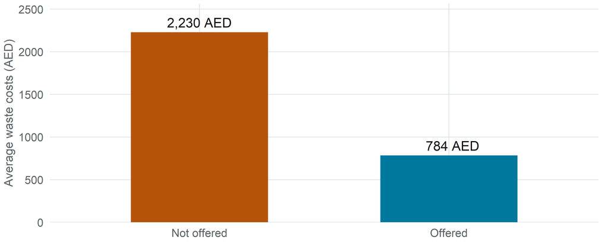

Businesses that were offered the programme spend less than those that were not. Did the programme cause that gap, and how big is the effect?

## Why that comparison is not the effect

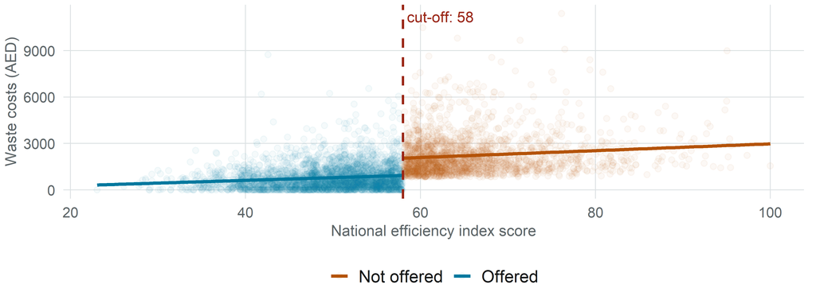

The two sides differ all the way across the index, exactly as they did this morning. A business scoring 30 is nothing like a business scoring 90. Most of that raw gap is who these businesses already were, not what the programme did.

# 2 · The idea, in plain terms 12 min

## Regression discontinuity in one sentence

Compare businesses **just below** the cut-off, who were offered the programme, with businesses **just above** it, who were not.

Right at the line, whether a business scores 58 or 59 is almost a matter of chance. So the two sides are alike in every way except one: which side got the programme.

The jump in costs **at the cut-off** is the estimated effect.

## When is regression discontinuity the right tool?

**Use it when:**

- A **threshold** decides who is in and who is out
- The score behind it is **continuous** and measured reliably
- Businesses **cannot precisely control** which side of the line they land on
- Enough units sit **near the line** to compare

**You have seen this shape before:**

- Test-score cut-offs for a scholarship
- Income thresholds for a subsidy or benefit
- Age limits for a service or pension
- Geographic boundaries for a policy
- A poverty score for social protection

Wherever a rule draws a line and access flips from one side to the other, there may be an RDD hiding in it.

## Your turn: the jump by hand

Take a narrow window on each side of the line and average the costs. Two averages, one subtraction.

**Just below (55 to 58), offered:** these businesses got the programme.

**Just above (59 to 62), not offered:** near-identical scores, but no programme.

The difference between the two averages is a first, rough estimate of the jump at the cut-off.

|  | Average cost |
| --- | --- |
| Just below (55 to 58): offered | ? |
| Just above (59 to 62): not offered | ? |
| Difference (the jump) | ? |

Ninety seconds. Which side do you expect to be lower, and by roughly how much?

## The answer, and the picture

|  | Average cost |
| --- | --- |
| Just below (55 to 58) | 864 |
| Just above (59 to 62) | 2,132 |
| Difference (the jump) | -1268 |

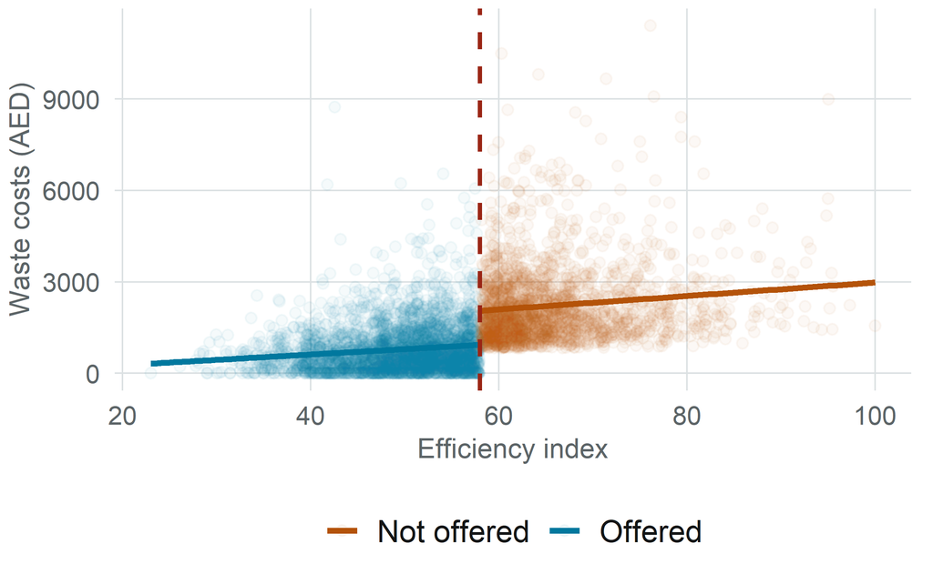

The regression does the same thing more carefully: it reads the size of the step at the line.

# Break 5 min

## Five minutes

We have the idea: compare the two sides right at the line, and read the jump.

After the break we open the actual table an evaluator would hand you, and find the one number that is the effect.

# 3 · Reading the output 15 min

## Three steps behind the table

```r
# Step 1. Would anyone fake their score?
#   Check no bunching just below 58.

# Step 2. Centre the running variable at
#   the cut-off, so 0 = the line.
r1 <- r1 %>% mutate(c0 = efficiency_index - 58)

# Step 3. Estimate the jump at the line,
#   adjusting for business characteristics.
#   The 'enrolled' coefficient is the effect.
m <- lm_robust(
  waste_management_costs ~ c0 * enrolled +
    age_manager + staff_size + foreign_owned +
    female_manager + business_area,   # and a few more
  data = r1)
```

- `c0`: the score, measured **from the line**. Zero is a business sitting exactly at 58.
- `enrolled`: which side, 1 offered and 0 not offered.
- `c0 * enrolled`: lets the two sides have different slopes, and reads the **step between them at the line**.

Step 1 is not a formality. If businesses can choose their side of the line, the whole comparison breaks. We come back to it in the next section.

## Running the regression

```r
m <- lm_robust(
  waste_management_costs ~
    c0 * enrolled +
    age_manager + age_deputy +
    female_manager + foreign_owned +
    staff_size + advanced_filtration +
    business_area +
    recycling_center_distance,
  data = r1)
```

| term | estimate | std. error |
| --- | --- | --- |
| (Intercept) | 2790.9 | 77.8 |
| c0 | 16.4 | 4.1 |
| enrolled | -905.0 | 44.4 |
| c0:enrolled | -19.3 | 4.6 |

*The four rows that carry meaning; business characteristics adjusted for in the background.*

Only one of these is the programme’s effect. Which one?

## Trap: the slope is not the effect

+16

`c0`: how costs change per point on the index, not the effect of the programme

This coefficient says costs drift as the score changes, moving along the line. That is a feature of who the businesses are, not of the programme. Reading it as the impact confuses the slope of the line with the step at the cut-off.

## The number that answers your question

-905 AED

`enrolled`: the jump in costs at the cut-off, adjusted for business characteristics

This is the step between the two sides, read right at the line: the number the decision rests on.

It is in the same ballpark as your by-hand jump, refined by accounting for the slope on each side of the line and for the businesses’ own characteristics.

## How sure are we?

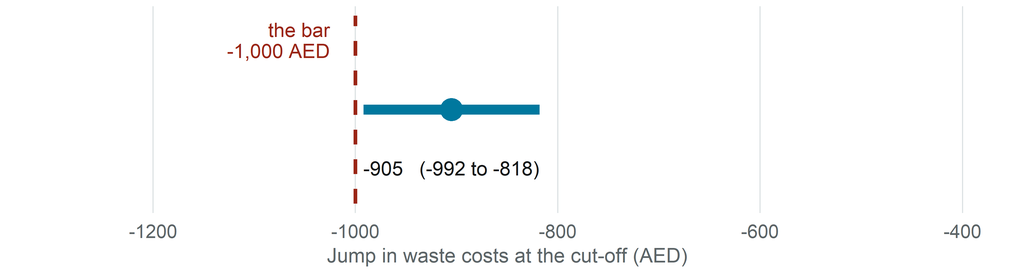

The estimate is **statistically significant**: we are confident the jump is not zero. It is also **short of the 1,000 AED bar** you set: significant is not the same as sufficient.

# 4 · The one question 13 min

## What RDD rests on

Difference-in-differences rested on parallel trends. Regression discontinuity rests on something you can picture just as easily:

Without the programme, costs would change **smoothly** across the cut-off. Nothing else jumps at 58.

If that holds, any sudden step at the line can only be the programme. The assumption is about the line being clean, not about the two halves of the market being similar.

## Threat one: could anyone choose their side?

If businesses could nudge their score to land just under 58 and get the programme, the two sides would no longer be alike: the just-below group would be the ones who worked the system.

The tell-tale sign is **bunching**: a pile-up of scores just below the line.

A formal check (the McCrary density test) puts a number on it. Here there is no bunching, and the index is a national score a single business cannot easily engineer.

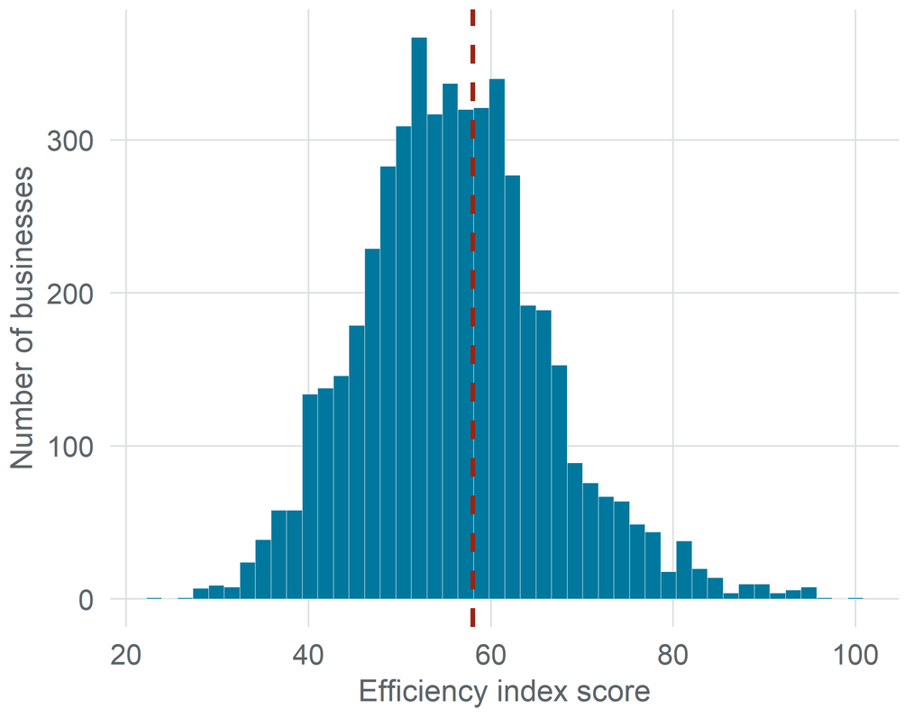

```r
r1 %>%
  ggplot(aes(efficiency_index)) +
  geom_histogram(bins = 46, fill = ACCENT,
                 colour = "white", linewidth = 0.15) +
  geom_vline(xintercept = CUTOFF, linetype = "dashed",
             colour = ALERT, linewidth = 1) +
  labs(x = "Efficiency index score",
       y = "Number of businesses") +
  theme_m2()
```

## Threat two: is the line used by anything else?

RDD credits the programme with **everything** that jumps at 58. If another policy, subsidy, or rule uses the same efficiency line, the step at the cut-off is the two effects added together, and RDD cannot separate them.

The question to ask the evaluator: is the cut-off at 58 used by any other programme, benefit, or obligation? If yes, what else changes there?

## Whose effect is this, really?

The jump is measured **at the line**. It is the effect for businesses scoring **near 58**: the ones on the margin of eligibility.

It says little about a business scoring 30, deep in the eligible range, which may respond very differently.

A national scale-up would reach businesses across the whole index, not just those near 58. RDD answers a question about the margin, not about everyone.

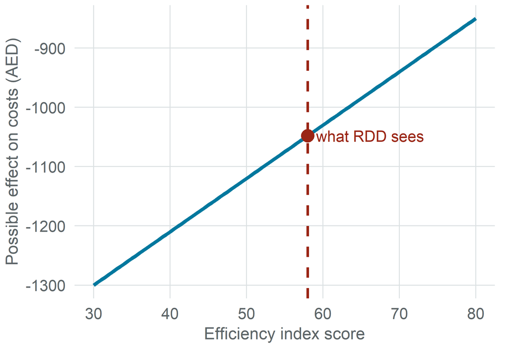

Keep this reach question in mind: it is easy to lose sight of when a summary is written for you.

# 5 · AI Snapshot 15 min

## Feeding the RDD table to AI

Suppose we paste the results table into AI and say: *“Explain these results.”* Here is the kind of answer it might give. Some of what it says may be wrong.

The regression discontinuity analysis shows that the GreenWaste Program reduced waste management costs by approximately 900 AED across all businesses in the country, a statistically significant effect (p < 0.01).

The coefficient on the efficiency index confirms the programme’s impact, showing that costs shift steadily as the score changes. The design compares businesses on either side of the eligibility threshold, so the estimate is clean.

Because the effect is statistically significant, the programme should be scaled up nationally.

In your groups, mark anything that looks wrong. Three minutes.

## What might be wrong here

**1 · It stretched a local result to everyone**

The jump is the effect for businesses **near 58**. Saying “across all businesses in the country” claims something RDD cannot measure.

**2 · It read the slope as the effect**

“Costs shift steadily as the score changes” describes the `c0` slope, not the jump at the line. That is the trap coefficient, dressed up as confirmation.

**3 · It ignored your decision rule**

About 900 AED is below the 1,000 AED bar. Significant is not the same as sufficient, and it recommended scale-up regardless.

**4 · It invented precision**

Notice: the answer was fluent, confident, and correctly formatted. Nothing in its tone marks the true sentences apart from the invented ones.

## The same table, a better prompt

### What people type

*“Explain these results.”*

- No decision rule
- No mention that the estimate is local
- No invitation to flag uncertainty
- Every gap filled with a confident guess

### What to type instead

*I am a commissioner, not an analyst. Below is a regression discontinuity table from a waste programme evaluation, with eligibility set by a score at a cut-off of 58. Our decision rule: costs must fall by at least 1,000 AED to justify national scale-up.*

*Before answering, ask me anything you need, including whether the cut-off is used by other programmes.*

*Then: (1) which single number is the effect, and which are not; (2) who does that effect apply to; (3) does it meet our rule; (4) what would have to be true for me to believe it.*

## Your turn

In your groups, using the table on your handout:

1. Run the **short prompt**. Read what you get.
2. Run the **full prompt card**. Answer the questions it asks you.
3. Compare: what did the second answer add, remove, or hedge, especially on **who the result applies to**?
4. Paste the second answer into a **fresh chat** and ask: *“Review this interpretation for errors and overstatement.”*

Step 4 matters. A second, clean conversation catches what the first one is already committed to.

## Debrief

- Did AI **generalise** the local effect to businesses far from the line?
- Did it **name the wrong coefficient** as the impact?
- Did it check the result against **your 1,000 AED rule**?
- Did it **invent** a p-value, a sample size, or a test?
- Did the second chat catch what the first missed?

Two habits, every time: tell the AI your decision rule and who the decision is about, and make it ask you questions before it answers.

# 6 · Abu Dhabi DCD 8 min

Programme

Running variable

The cut-off

Outcome

Decision

Shared cut-off?

Apply the same steps, in order:

1. Which coefficient is the jump at the cut-off, and which is the slope?
2. Does it clear the threshold that matters for this decision?
3. Could anyone have chosen their side of the line?
4. Is the cut-off used by anything else?
5. Who does this effect apply to, and who would a scale-up reach?

Verdict round: act on it, act with caveats, or send it back?

# 7 · Closing 4 min

## Three questions to ask any evaluator presenting RDD

**1 · “Could anyone choose their side of the line?”**

If scores can be nudged to gain eligibility, the two sides are no longer comparable. Ask what the density check showed.

**2 · “Is this cut-off used by any other programme?”**

If so, the jump mixes two effects and cannot be read as this programme alone.

**3 · “Who does this effect apply to, and does a local result answer a national question?”**

The estimate is for businesses near the line. Scale-up is about everyone.

## Where this sits: Day 2 scoreboard

| Method | Estimate | Verdict |
| --- | --- | --- |
| Difference-in-differences | -816 AED | Below the bar: do not scale |
| Regression discontinuity | -905 AED | Below the bar: do not scale |
| Matching | pending | (next session) |
| Randomised trial | -1,014 AED (Module 1) | Above the bar: scale up |

Two methods now say do not scale. The randomised trial said scale up. Same programme, same data, different answers.

## Why might RDD differ from the randomised result?

The randomised trial found a larger effect (-1,014 AED) and cleared the bar. RDD, on the same programme, did not. Why?

- RDD measures the effect only **at the cut-off**, for marginal businesses
- The randomised trial measures an **average** across the businesses in it
- If the programme works better for some businesses than others, these two numbers should not be expected to match

## Next session

**Reading Matching Results**: when there was no threshold and no randomisation, how an evaluator builds a comparison group by pairing similar units, and what has to be true for that comparison to be believed.

The reach question stays with us: matching, like RDD, answers a question about a particular set of units, and knowing which ones is half of reading the result.